# Wine Quality

Guilherme Brunhole

July 20, 2017

# P4 - Explore e resuma os dados

## Bibliotecas utilizadas no projeto:

```r
library('ggplot2')
library(readr)
library(grid)
library(gridExtra)
library(dplyr)
```

## Carregando os dados:

### Funções auxiliares:

Essas funções foram criadas para facilitar o entendimento do código e também diminuir seu tamanho na hora da criação dos gráficos. A primeira função, *box_plot_func* é para a criação de um boxplot separado pela coluna *quality.label*, a segunda função, *pont_plot_func* é para a criação de um gráfico de dispersão agrupado pela coluna *quality.label* e a terceira função *density_plot_func* é para a criação de um gráfico de densidade.

### Qual é a estrutura do conjunto de dados?

```r
names(wineQualityReds)
```

```
##  [1] "rn"                   "fixed.acidity"        "volatile.acidity"
##  [4] "citric.acid"          "residual.sugar"       "chlorides"
##  [7] "free.sulfur.dioxide"  "total.sulfur.dioxide" "density"
## [10] "pH"                   "sulphates"            "alcohol"
## [13] "quality"
```

```
##        rn         fixed.acidity   volatile.acidity   citric.acid
##  Min.   :   1.0   Min.   : 4.60   Min.   :   0.12   Min.   :0.000
##  1st Qu.: 400.5   1st Qu.: 7.10   1st Qu.:   0.40   1st Qu.:0.090
##  Median : 800.0   Median : 7.90   Median :   0.52   Median :0.260
##  Mean   : 800.0   Mean   : 8.32   Mean   :  84.83   Mean   :0.271
##  3rd Qu.:1199.5   3rd Qu.: 9.20   3rd Qu.:   0.66   3rd Qu.:0.420
##  Max.   :1599.0   Max.   :15.90   Max.   :1185.00   Max.   :1.000
##
##  residual.sugar     chlorides      free.sulfur.dioxide
##  Min.   : 0.900   Min.   :  0.05   Min.   : 1.00
##  1st Qu.: 1.900   1st Qu.: 65.00   1st Qu.: 7.00
##  Median : 2.200   Median : 77.00   Median :14.00
##  Mean   : 2.539   Mean   : 77.47   Mean   :15.87
##  3rd Qu.: 2.600   3rd Qu.: 88.00   3rd Qu.:21.00
##  Max.   :15.500   Max.   :611.00   Max.   :72.00
##
##  total.sulfur.dioxide    density                pH          sulphates
##  Min.   :  6.00       Min.   :   0.9901   Min.   :2.740   Min.   :0.3300
##  1st Qu.: 22.00       1st Qu.:   0.9956   1st Qu.:3.210   1st Qu.:0.5500
##  Median : 38.00       Median :   0.9968   Median :3.310   Median :0.6200
##  Mean   : 46.43       Mean   :  58.3215   Mean   :3.311   Mean   :0.6581
##  3rd Qu.: 62.00       3rd Qu.:   0.9982   3rd Qu.:3.400   3rd Qu.:0.7300
##  Max.   :289.00       Max.   :1001.0000   Max.   :4.010   Max.   :2.0000
##  NA's   :2
##     alcohol         quality
##  Min.   : 8.40   Min.   :3.000
##  1st Qu.: 9.50   1st Qu.:5.000
##  Median :10.20   Median :6.000
##  Mean   :10.42   Mean   :5.636
##  3rd Qu.:11.10   3rd Qu.:6.000
##  Max.   :14.90   Max.   :8.000
##
```

### Algumas observações sobre nosso conjunto de dados:

Removendo os valores NA’s da coluna *total.sulfur.dioxide*:

```r
wineQualityReds <- na.omit(wineQualityReds)

summary(wineQualityReds)
```

```
##        rn         fixed.acidity    volatile.acidity   citric.acid
##  Min.   :   1.0   Min.   : 4.600   Min.   :   0.12   Min.   :0.0000
##  1st Qu.: 400.0   1st Qu.: 7.100   1st Qu.:   0.40   1st Qu.:0.0900
##  Median : 799.0   Median : 7.900   Median :   0.52   Median :0.2600
##  Mean   : 799.4   Mean   : 8.322   Mean   :  84.94   Mean   :0.2713
##  3rd Qu.:1198.0   3rd Qu.: 9.200   3rd Qu.:   0.66   3rd Qu.:0.4200
##  Max.   :1599.0   Max.   :15.900   Max.   :1185.00   Max.   :1.0000
##  residual.sugar     chlorides      free.sulfur.dioxide
##  Min.   : 0.900   Min.   :  0.05   Min.   : 1.00
##  1st Qu.: 1.900   1st Qu.: 65.00   1st Qu.: 7.00
##  Median : 2.200   Median : 77.00   Median :14.00
##  Mean   : 2.537   Mean   : 77.45   Mean   :15.83
##  3rd Qu.: 2.600   3rd Qu.: 88.00   3rd Qu.:21.00
##  Max.   :15.500   Max.   :611.00   Max.   :72.00
##  total.sulfur.dioxide    density                pH          sulphates
##  Min.   :  6.00       Min.   :   0.9901   Min.   :2.740   Min.   :0.3300
##  1st Qu.: 22.00       1st Qu.:   0.9956   1st Qu.:3.210   1st Qu.:0.5500
##  Median : 38.00       Median :   0.9968   Median :3.310   Median :0.6200
##  Mean   : 46.43       Mean   :  58.3933   Mean   :3.311   Mean   :0.6584
##  3rd Qu.: 62.00       3rd Qu.:   0.9982   3rd Qu.:3.400   3rd Qu.:0.7300
##  Max.   :289.00       Max.   :1001.0000   Max.   :4.010   Max.   :2.0000
##     alcohol         quality
##  Min.   : 8.40   Min.   :3.000
##  1st Qu.: 9.50   1st Qu.:5.000
##  Median :10.20   Median :6.000
##  Mean   :10.42   Mean   :5.637
##  3rd Qu.:11.10   3rd Qu.:6.000
##  Max.   :14.90   Max.   :8.000
```

# Seção de Gráficos Univariados

O primeiro gráfico que farei é um histograma simples utilizando a qualidade do vinho como eixo X. Quero saber qual é o nível dos vinhos em nosso dataset!

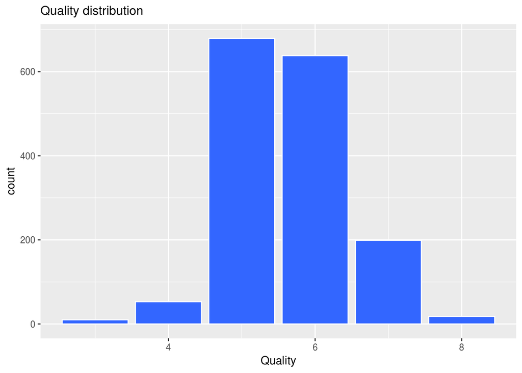

Vamos olhar rapidamente para as outras variáveis!

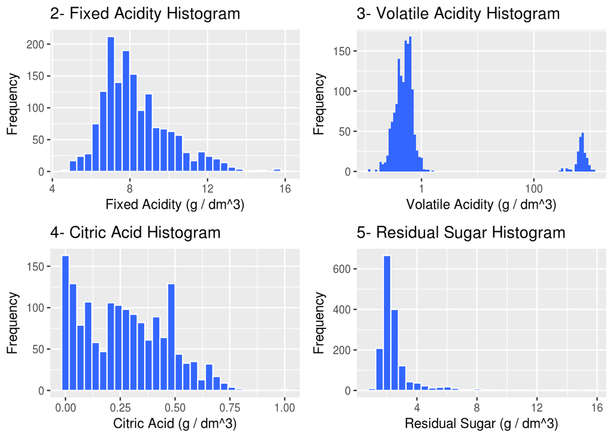

```r
plot_fix_acid <- ggplot(wineQualityReds, aes(x = fixed.acidity))+
                      geom_histogram(color="white", fill="#3366FF") +
                      ylab('Frequency') +
                      xlab('Fixed Acidity (g / dm^3)') +
                      labs(title='2- Fixed Acidity Histogram')

plot_vol_acid <- ggplot(wineQualityReds, aes(x = volatile.acidity))+
                    ylab('Frequency') +
                    xlab('Volatile Acidity (g / dm^3)') +
                    labs(title='3- Volatile Acidity Histogram') +
                    geom_histogram(fill="#3366FF",bins = 100) +
                    scale_x_log10()

plot_cit_acid <- ggplot(wineQualityReds, aes(x = citric.acid))+
                    geom_histogram(color="white", fill="#3366FF") +
                    ylab('Frequency') +
                    xlab('Citric Acid (g / dm^3)') +
                    labs(title='4- Citric Acid Histogram')

plot_res_sugar <- ggplot(wineQualityReds, aes(x = residual.sugar))+
                    geom_histogram(color="white", fill="#3366FF") +
                    ylab('Frequency') +
                    xlab('Residual Sugar (g / dm^3)') +
                    labs(title='5- Residual Sugar Histogram')

plot_chlorides <- ggplot(wineQualityReds, aes(x = chlorides))+
                    geom_histogram(color="white", fill="#3366FF", bins = 100) +
                    ylab('Frequency') +
                    xlab('Chlorides (g / dm^3)') +
                    labs(title='6- Chlorides Histogram')

plot_so2 <- ggplot(wineQualityReds, aes(x = total.sulfur.dioxide))+
                      geom_histogram(color="white", fill="#3366FF") +
                      ylab('Frequency') +
                      xlab('SO2 (g / dm^3)') +
                      labs(title='7- SO2 Histogram')

plot_ph <- ggplot(wineQualityReds, aes(x = pH))+
                      geom_histogram(color="white", fill="#3366FF") +
                      ylab('Frequency') +
                      xlab('pH') +
                      labs(title='8- pH Histogram') +
                      scale_x_continuous(breaks = seq(0,4,0.2))

plot_alcohol <- ggplot(wineQualityReds, aes(x = alcohol))+
                          geom_histogram(color="white", fill="#3366FF") +
                          ylab('Frequency') +
                          xlab('Alcohol (% by volume)') +
                          labs(title='9- Alcohol Histogram')

grid.arrange(plot_fix_acid,plot_vol_acid,plot_cit_acid,plot_res_sugar,ncol=2)
```

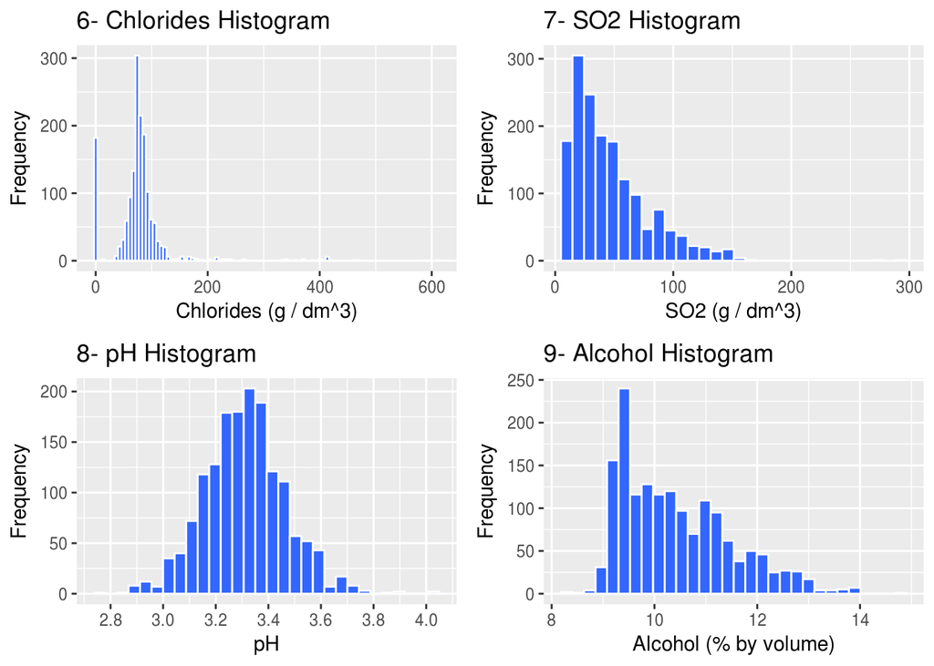

```r
grid.arrange(plot_chlorides,plot_so2,plot_ph,plot_alcohol,ncol=2)
```

### Algumas modificações:

Vamos fazer uma pequena alteração na variável *volatile.acidity* para corrigirmos o eixo do gráfico.

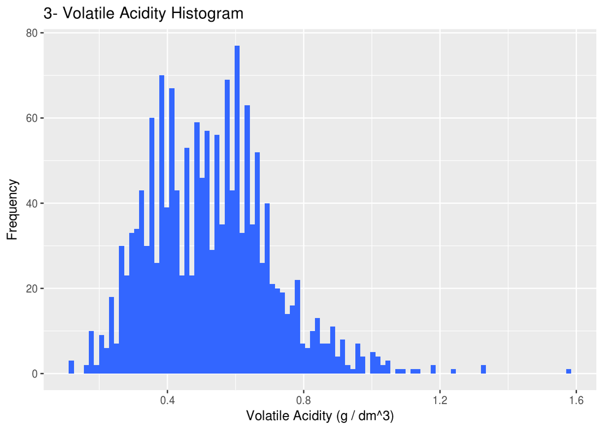

```r
wineQualityReds$volatile.acidity <- ifelse(wineQualityReds$volatile.acidity > 100,
                                           wineQualityReds$volatile.acidity/1000,
                                           wineQualityReds$volatile.acidity)

ggplot(wineQualityReds, aes(x = volatile.acidity))+
                    ylab('Frequency') +
                    xlab('Volatile Acidity (g / dm^3)') +
                    labs(title='3- Volatile Acidity Histogram') +
                    geom_histogram(fill="#3366FF",bins = 100)
```

Pronto, agora o gráfico está com uma distribuição correta :)

### Algumas observações:

- *Gráfico 1*: Como podemos perceber, a maioria dos nossos vinhos são de uma qualidade relativamente boa (5 ou 6)
- *Gráfico 2*: Essa variável possue uma distribuição quase que normal, com uma leve inclinação positiva
- *Gráfico 3*: Após corrigirmos os dados dessa coluna, o gráfico apresentou uma inclinação positiva
- *Gráfico 4*: Aqui esse gráfico apresentou uma inclinação positiva com uma calda relativamente curta
- *Gráfico 5*: Distribuição com inclinação positiva e uma calda longa
- *Gráfico 6*: Distribuição positivamente inclinada com uma longa cauda a direita
- *Gráfico 7*: Distribuição positivamente inclinada com uma longa cauda a direita
- *Gráfico 8*: Esse é o que mais apresentou uma distribuição normal :)
- *Gráfico 9*: Distribuição positivamente inclinada com uma leve cauda

### Quais são os principais atributos de interesse deste conjunto de dados?

Para descobrirmos quais são os principais atributos aqui, vamos verificar quais tem que correlação com a coluna quality. Para isso existe a função *cor()* do r

```
##                   rn        fixed.acidity     volatile.acidity
##           0.06758909           0.12320006          -0.39022587
##          citric.acid       residual.sugar            chlorides
##           0.22536054           0.01498493          -0.07217018
##  free.sulfur.dioxide total.sulfur.dioxide              density
##          -0.04769854          -0.18434369          -0.04190279
##                   pH            sulphates              alcohol
##          -0.05848341           0.25051925           0.47572001
##              quality
##           1.00000000
```

Como podemos observar, os principais atributos desse conjunto de dados são o *alcohol*, *sulphates*, *volatile.acidity* e *citric.acid*

### Você criou novas variáveis a partir dos atributos existentes no conjunto de dados?

```r
wineQualityReds$quality.label <- cut(wineQualityReds$quality, c(3,4,6,10),
                                     labels = c("ruim","bom","ótimo"),
                                     include.lowest = T)
summary(wineQualityReds$quality.label)
```

```
##  ruim   bom ótimo
##    63  1317   217
```

### Quais outros atributos você acha que podem lhe auxiliar na investigação destes atributos de interesse?

Vamos olhar quais atributos são mais relevantes para cada uma das três variáveis mencionadas acima! :)

### Ácido Cítrico

```r
cor(wineQualityReds[,-14])[,'citric.acid']
```

```
##                   rn        fixed.acidity     volatile.acidity
##          -0.15197133           0.67120591          -0.55228351
##          citric.acid       residual.sugar            chlorides
##           1.00000000           0.14607451           0.15334547
##  free.sulfur.dioxide total.sulfur.dioxide              density
##          -0.05558572           0.03724338           0.05179771
##                   pH            sulphates              alcohol
##          -0.54399501           0.31130106           0.10857619
##              quality
##           0.22536054
```

Aqui podemos ver que o que mais influencia é o atributo *fixed.acidity*.

### Sulfito

```r
cor(wineQualityReds[,-14])[,'sulphates']
```

```
##                   rn        fixed.acidity     volatile.acidity
##         -0.123859096          0.181768671         -0.260407811
##          citric.acid       residual.sugar            chlorides
##          0.311301059          0.007463648          0.224863729
##  free.sulfur.dioxide total.sulfur.dioxide              density
##          0.057284788          0.044465293          0.017771545
##                   pH            sulphates              alcohol
##         -0.198006469          1.000000000          0.092392709
##              quality
##          0.250519246
```

### Álcool

```r
cor(wineQualityReds[,-14])[,'alcohol']
```

```
##                   rn        fixed.acidity     volatile.acidity
##           0.24658445          -0.06280815          -0.20180471
##          citric.acid       residual.sugar            chlorides
##           0.10857619           0.04349416          -0.17230094
##  free.sulfur.dioxide total.sulfur.dioxide              density
##          -0.06626454          -0.20484057          -0.03226594
##                   pH            sulphates              alcohol
##           0.20501427           0.09239271           1.00000000
##              quality
##           0.47572001
```

Aqui o *ph* é o que mais tem influência nesse atributo!

Relembrando: - *fixed.acidity* - *chlorides* - *ph* - *sulphates*

Agora que listamos as outras quatro variáveis que serão usadas, mais à frente iremos analisá-las também!

# Análise Bivariada

Vou fazer algumas análises abaixo para verificarmos a relação entre duas variáveis :)

Primeiro irei utilizar da biblioteca *lsr*, a função *correlate* que me dá a relação entre duas variávies!

```
##
## CORRELATIONS
## ============
## - correlation type:  pearson
## - correlations shown only when both variables are numeric
##
##                          rn fixed.acidity volatile.acidity citric.acid
## rn                        .        -0.268           -0.010      -0.152
## fixed.acidity        -0.268             .           -0.256       0.671
## volatile.acidity     -0.010        -0.256                .      -0.552
## citric.acid          -0.152         0.671           -0.552           .
## residual.sugar       -0.033         0.117            0.001       0.146
## chlorides            -0.076         0.086            0.046       0.153
## free.sulfur.dioxide   0.087        -0.151           -0.013      -0.056
## total.sulfur.dioxide -0.119        -0.112            0.076       0.037
## density              -0.098         0.055            0.015       0.052
## pH                    0.137        -0.685            0.236      -0.544
## sulphates            -0.124         0.182           -0.260       0.311
## alcohol               0.247        -0.063           -0.202       0.109
## quality               0.068         0.123           -0.390       0.225
## quality.label             .             .                .           .
##                      residual.sugar chlorides free.sulfur.dioxide
## rn                           -0.033    -0.076               0.087
## fixed.acidity                 0.117     0.086              -0.151
## volatile.acidity              0.001     0.046              -0.013
## citric.acid                   0.146     0.153              -0.056
## residual.sugar                    .     0.049               0.183
## chlorides                     0.049         .              -0.034
## free.sulfur.dioxide           0.183    -0.034                   .
## total.sulfur.dioxide          0.202    -0.009               0.669
## density                      -0.006     0.025              -0.003
## pH                           -0.085    -0.189               0.074
## sulphates                     0.007     0.225               0.057
## alcohol                       0.043    -0.172              -0.066
## quality                       0.015    -0.072              -0.048
## quality.label                     .         .                   .
##                      total.sulfur.dioxide density     pH sulphates alcohol
## rn                                 -0.119  -0.098  0.137    -0.124   0.247
## fixed.acidity                      -0.112   0.055 -0.685     0.182  -0.063
## volatile.acidity                    0.076   0.015  0.236    -0.260  -0.202
```

[output cut: 11 more lines]

```
##                      quality quality.label
## rn                     0.068             .
## fixed.acidity          0.123             .
## volatile.acidity      -0.390             .
## citric.acid            0.225             .
## residual.sugar         0.015             .
## chlorides             -0.072             .
## free.sulfur.dioxide   -0.048             .
## total.sulfur.dioxide  -0.184             .
## density               -0.042             .
## pH                    -0.058             .
## sulphates              0.251             .
## alcohol                0.476             .
## quality                    .             .
## quality.label              .             .
```

Legal né? Mas é uma tabela, então é dificil tirar uma conclusão rápida!

Abaixo vou fazer um plot disso e você vai poder perceber o quão mais fácil fica :)

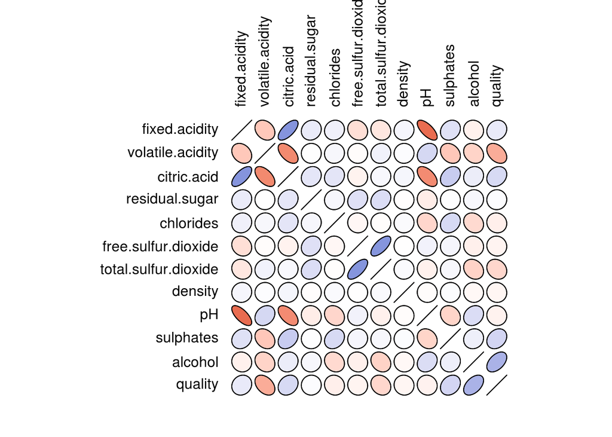

```r
library(ellipse)
#craete new dataframe without categorical vars
numeric_vars <- names(wineQualityReds) %in% c("quality.label", "rn")
rw_num <- wineQualityReds[!numeric_vars]
ctab <- cor(rw_num)
#plot which show correlation in more convenient way
colorfun <- colorRamp(c("#CC0000","white","#3366CC"), space="Lab")
plotcorr(ctab, mar = c(0,0,0,0), col=rgb(colorfun((ctab+1)/2),
                                         maxColorValue=255))
```

### Discuta sobre alguns dos relacionamentos observados nesta parte da investigação. Como os atributos de interesse variaram no conjunto de dados?

Apenas uma explicação rápida, quanto mais azul e mais inclinado para a direita, mais positivamente correlacionada as variáveis são. E quanto mais vermelho e mais inclinado para a esquerda, mais negativamente correlacionadas elas são!

Só de bater o olho já conseguimos ver 4 fortes correlações (2 positivas e 2 negativas) :)

Abaixo um resumo por variável:

E a nossa principal:

- *quality*: aparentemente as que mais têm influência positiva nessa coluna são fixed.acidity, citric.acid, sulphates e alcohol

Vamos aqui olhar variável à variável em relação à nossa de qualidade :)

#### Citric Acid

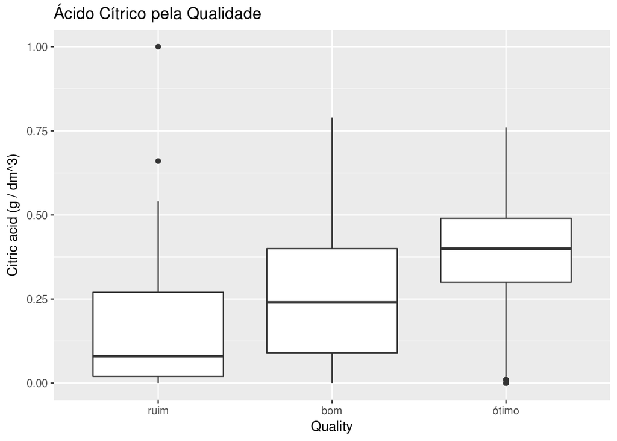

```r
box_plot_func(y_str = "citric.acid",
              yl = "Citric acid (g / dm^3)",
              t = "Ácido Cítrico pela Qualidade")
```

```r
by(wineQualityReds$citric.acid, wineQualityReds$quality.label,  summary)
```

```
## wineQualityReds$quality.label: ruim
##    Min. 1st Qu.  Median    Mean 3rd Qu.    Max.
##  0.0000  0.0200  0.0800  0.1737  0.2700  1.0000
## --------------------------------------------------------
## wineQualityReds$quality.label: bom
##    Min. 1st Qu.  Median    Mean 3rd Qu.    Max.
##  0.0000  0.0900  0.2400  0.2587  0.4000  0.7900
## --------------------------------------------------------
## wineQualityReds$quality.label: ótimo
##    Min. 1st Qu.  Median    Mean 3rd Qu.    Max.
##  0.0000  0.3000  0.4000  0.3765  0.4900  0.7600
```

Muito bom esse plot! Podemos ver que existem pouqíssimos outliers :D Além disso, pode-se perceber que realmente essa coluna tem uma influência na qualidade do vinho

#### SO2

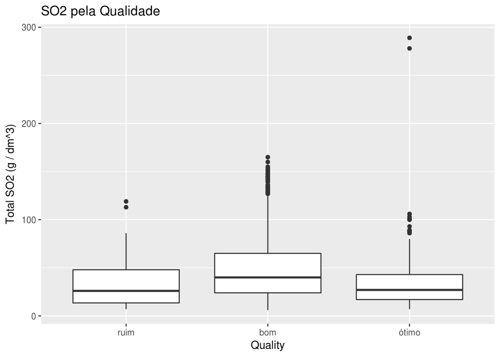

```r
box_plot_func(y_str = "total.sulfur.dioxide",
              yl = "Total SO2 (g / dm^3)",
              t = "SO2 pela Qualidade")
```

```r
by(wineQualityReds$total.sulfur.dioxide, wineQualityReds$quality.label,  summary)
```

```
## wineQualityReds$quality.label: ruim
##    Min. 1st Qu.  Median    Mean 3rd Qu.    Max.
##    7.00   13.50   26.00   34.44   48.00  119.00
## --------------------------------------------------------
## wineQualityReds$quality.label: bom
##    Min. 1st Qu.  Median    Mean 3rd Qu.    Max.
##     6.0    24.0    40.0    48.9    65.0   165.0
## --------------------------------------------------------
## wineQualityReds$quality.label: ótimo
##    Min. 1st Qu.  Median    Mean 3rd Qu.    Max.
##    7.00   17.00   27.00   34.89   43.00  289.00
```

Aqui podemos já perceber que existem diversos outliers. Além disso não há muito o que comentar, já que possue um comportamento um tanto quanto similar entre os tipos de vinho.

#### Residual Sugar

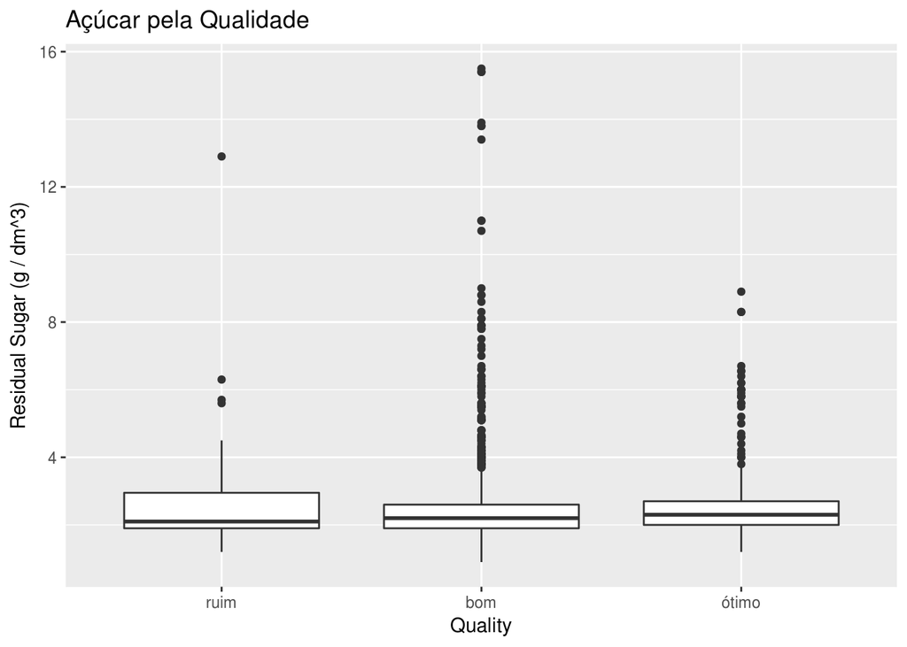

```r
box_plot_func(y_str = "residual.sugar",
              yl = "Residual Sugar (g / dm^3)",
              t = "Açúcar pela Qualidade")
```

```r
by(wineQualityReds$residual.sugar, wineQualityReds$quality.label,  summary)
```

```
## wineQualityReds$quality.label: ruim
##    Min. 1st Qu.  Median    Mean 3rd Qu.    Max.
##   1.200   1.900   2.100   2.685   2.950  12.900
## --------------------------------------------------------
## wineQualityReds$quality.label: bom
##    Min. 1st Qu.  Median    Mean 3rd Qu.    Max.
##   0.900   1.900   2.200   2.501   2.600  15.500
## --------------------------------------------------------
## wineQualityReds$quality.label: ótimo
##    Min. 1st Qu.  Median    Mean 3rd Qu.    Max.
##   1.200   2.000   2.300   2.709   2.700   8.900
```

Existem muitos outliers, principalmente em vinhos *bons*, mas no geral essa coluna tem um comportamento similar entre os diversos tipos.

#### pH

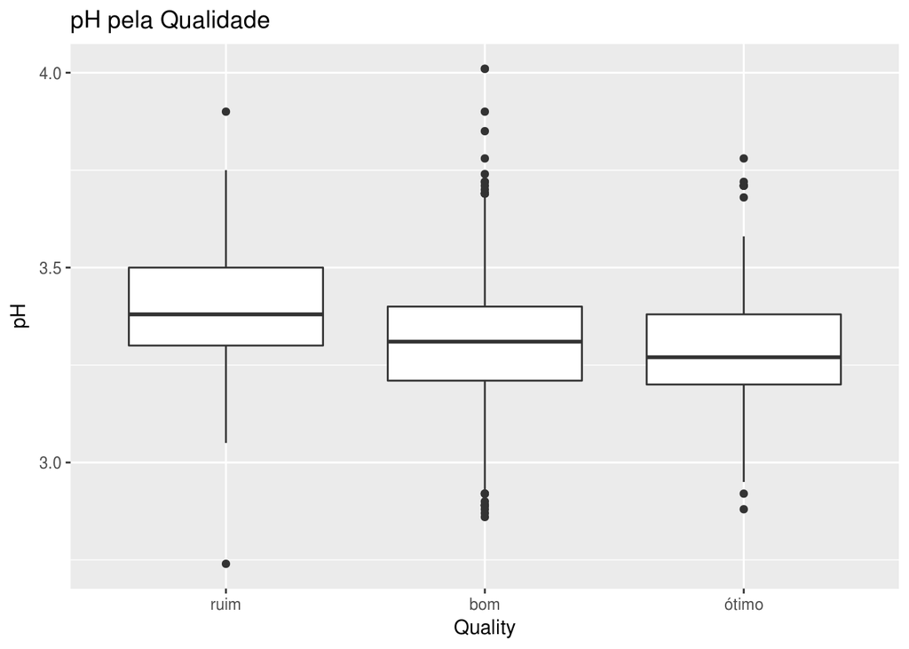

```r
box_plot_func(y_str = "pH",
              yl = "pH",
              t = "pH pela Qualidade")
```

```r
by(wineQualityReds$pH, wineQualityReds$quality.label,  summary)
```

```
## wineQualityReds$quality.label: ruim
##    Min. 1st Qu.  Median    Mean 3rd Qu.    Max.
##   2.740   3.300   3.380   3.384   3.500   3.900
## --------------------------------------------------------
## wineQualityReds$quality.label: bom
##    Min. 1st Qu.  Median    Mean 3rd Qu.    Max.
##   2.860   3.210   3.310   3.311   3.400   4.010
## --------------------------------------------------------
## wineQualityReds$quality.label: ótimo
##    Min. 1st Qu.  Median    Mean 3rd Qu.    Max.
##   2.880   3.200   3.270   3.289   3.380   3.780
```

Existem alguns outliers, principalmente em vinhos *bons*, mas no geral essa coluna tem um comportamento similar entre os diversos tipos.

#### SO2

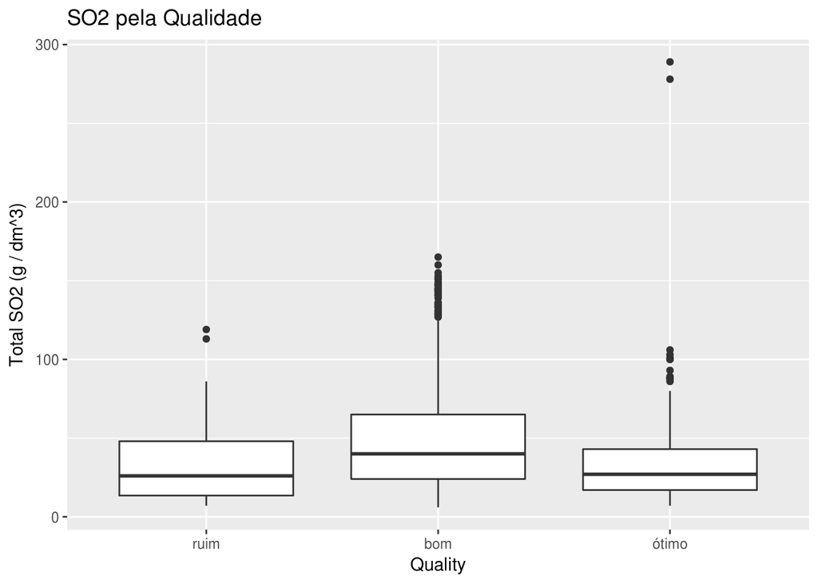

```r
box_plot_func(y_str = "total.sulfur.dioxide",
              yl = "Total SO2 (g / dm^3)",
              t = "SO2 pela Qualidade")
```

```r
by(wineQualityReds$total.sulfur.dioxide, wineQualityReds$quality.label,  summary)
```

```
## wineQualityReds$quality.label: ruim
##    Min. 1st Qu.  Median    Mean 3rd Qu.    Max.
##    7.00   13.50   26.00   34.44   48.00  119.00
## --------------------------------------------------------
## wineQualityReds$quality.label: bom
##    Min. 1st Qu.  Median    Mean 3rd Qu.    Max.
##     6.0    24.0    40.0    48.9    65.0   165.0
## --------------------------------------------------------
## wineQualityReds$quality.label: ótimo
##    Min. 1st Qu.  Median    Mean 3rd Qu.    Max.
##    7.00   17.00   27.00   34.89   43.00  289.00
```

#### Alcohol

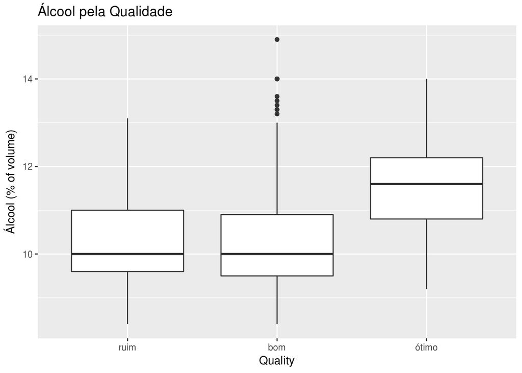

```r
box_plot_func(y_str = "alcohol",
              yl = "Álcool (% of volume)",
              t = "Álcool pela Qualidade")
```

```r
by(wineQualityReds$alcohol, wineQualityReds$quality.label,  summary)
```

```
## wineQualityReds$quality.label: ruim
##    Min. 1st Qu.  Median    Mean 3rd Qu.    Max.
##    8.40    9.60   10.00   10.22   11.00   13.10
## --------------------------------------------------------
## wineQualityReds$quality.label: bom
##    Min. 1st Qu.  Median    Mean 3rd Qu.    Max.
##    8.40    9.50   10.00   10.25   10.90   14.90
## --------------------------------------------------------
## wineQualityReds$quality.label: ótimo
##    Min. 1st Qu.  Median    Mean 3rd Qu.    Max.
##    9.20   10.80   11.60   11.52   12.20   14.00
```

Aqui conseguimos ver que os vinhos classificados como *ótimos* possuem uma quantidade maior de álcool em sua composição. Vinhos *bons* e *ruins* são praticamente idênticos.

#### Sulphates

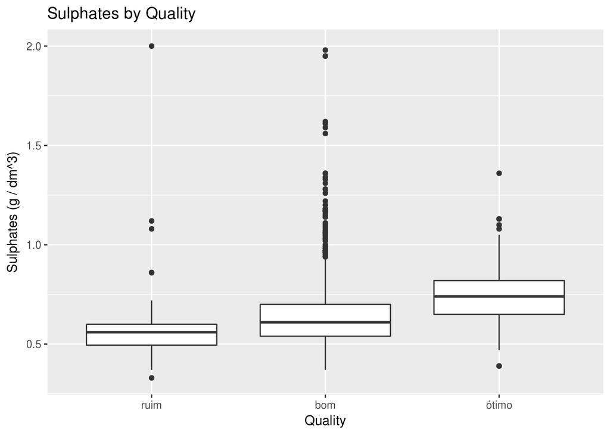

```r
box_plot_func(y_str = "sulphates",
              yl = "Sulphates (g / dm^3)",
              t = "Sulphates by Quality")
```

```r
by(wineQualityReds$sulphates, wineQualityReds$quality.label,  summary)
```

```
## wineQualityReds$quality.label: ruim
##    Min. 1st Qu.  Median    Mean 3rd Qu.    Max.
##  0.3300  0.4950  0.5600  0.5922  0.6000  2.0000
## --------------------------------------------------------
## wineQualityReds$quality.label: bom
##    Min. 1st Qu.  Median    Mean 3rd Qu.    Max.
##  0.3700  0.5400  0.6100  0.6476  0.7000  1.9800
## --------------------------------------------------------
## wineQualityReds$quality.label: ótimo
##    Min. 1st Qu.  Median    Mean 3rd Qu.    Max.
##  0.3900  0.6500  0.7400  0.7435  0.8200  1.3600
```

Muito legal essa variável, podemos ver que ela possui um comportamento diferente para as três classificações de qualidade :)

#### Chlorides

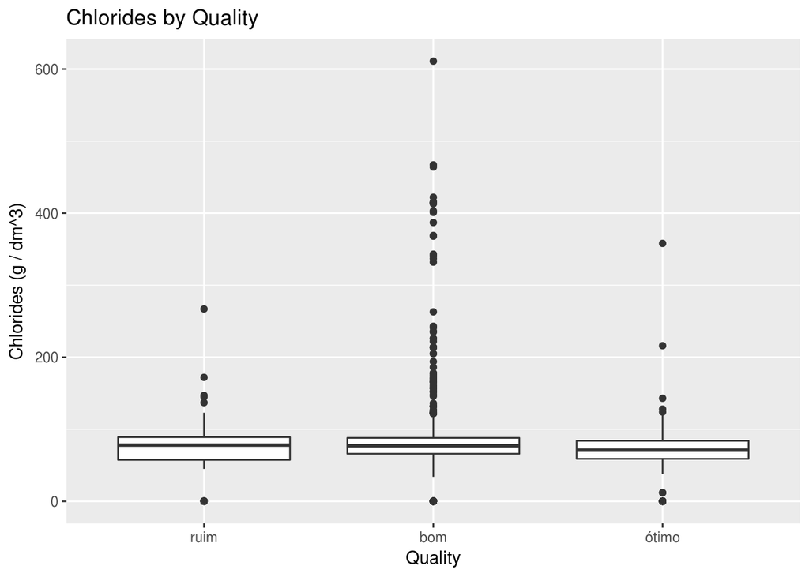

```r
box_plot_func(y_str = "chlorides",
              yl = "Chlorides (g / dm^3)",
              t = "Chlorides by Quality")
```

```r
by(wineQualityReds$chlorides, wineQualityReds$quality.label,  summary)
```

```
## wineQualityReds$quality.label: ruim
##    Min. 1st Qu.  Median    Mean 3rd Qu.    Max.
##    0.05   57.50   78.00   73.05   89.00  267.00
## --------------------------------------------------------
## wineQualityReds$quality.label: bom
##    Min. 1st Qu.  Median    Mean 3rd Qu.    Max.
##    0.05   66.00   77.00   79.01   88.00  611.00
## --------------------------------------------------------
## wineQualityReds$quality.label: ótimo
##    Min. 1st Qu.  Median    Mean 3rd Qu.    Max.
##    0.05   59.00   71.00   69.24   84.00  358.00
```

Possui um comportamento um tanto quanto similar entre as qualidades *boa* e *ruim*, mas já para a *ótima* ela tem um comportamento diferente :)

### Você observou algum relacionamento interessante entre os outros atributos (os que não são de interesse)?

Aprentemente a qualidade do vinho depende das seguintes características: - Álcool - Sulfatos - Volatilidade do ácido - Ácido cítrico

# Seção de Gráficos Multivariados

### Chlorides vs pH by Quality

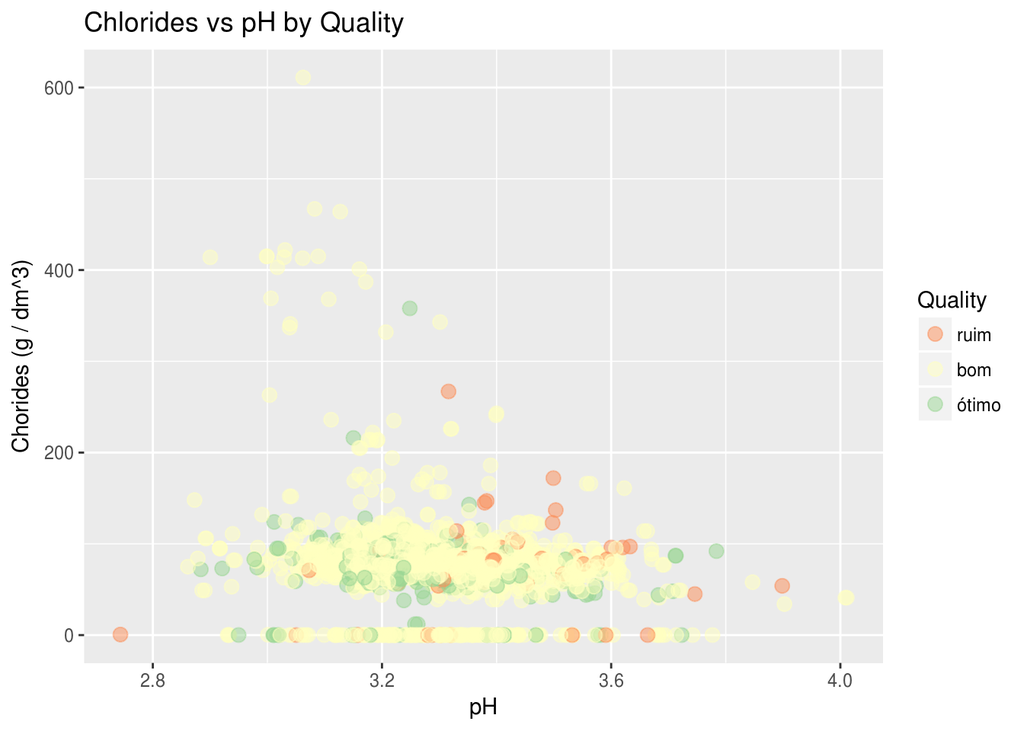

Não consegui tirar nenhuma conclusão a partir desse gráfico.

### Sulphates vs pH by Quality

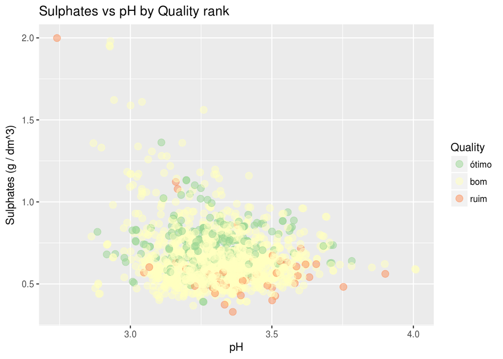

Essa visualização ficou um tanto quanto poluída né? Irei refazê-la, porém excluindo os vinhos bons… vamos ver como que fica!

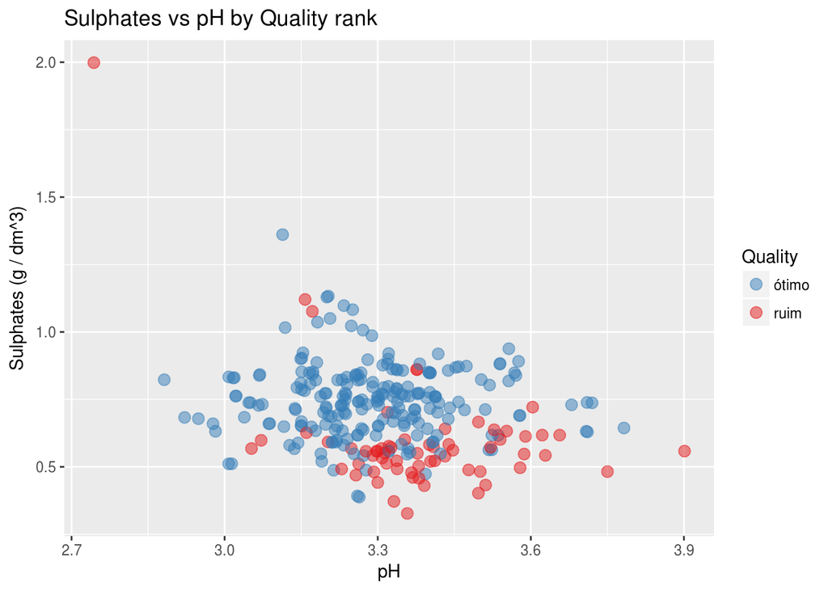

Agora já fica muito mais claro uma conclusão :) Podemos ver claramente que em geral os vinhos classificados como ruins possuem uma quantidade menor de *sulphates* e um *pH* relativamente mais alto em alguns casos.

### Citric acid vs pH by Quality rank

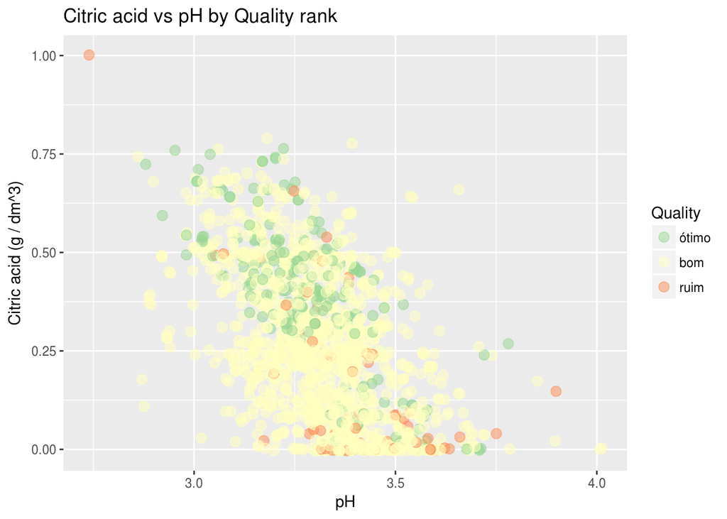

Aparentemente, vinhos com um pH menor do que 3.5 e com mais de 0.25 de ácido cítrico tendem a ter uma qualidade superior aos outros :)

### Vamos olhar para a coluna *sulphates* mais de perto

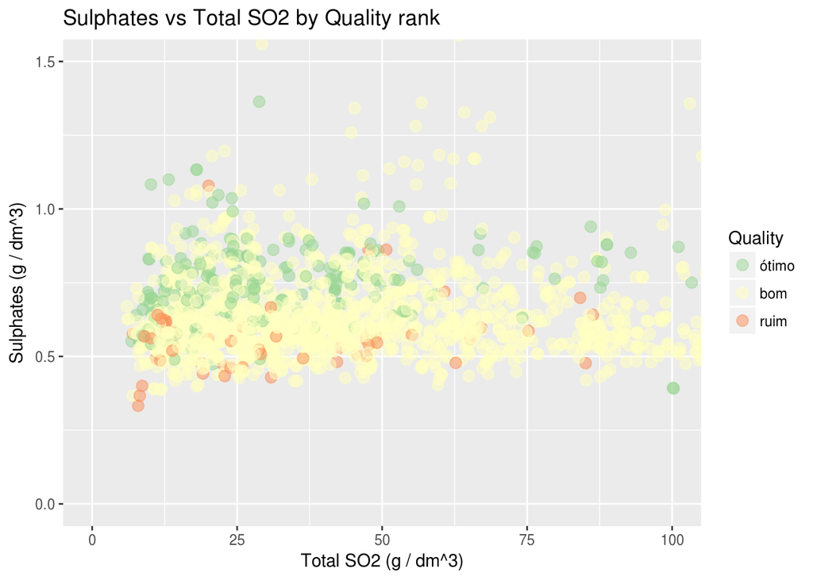

Parece que vinhos bons tem menos de 50g de SO2 em sua composição! Mais uma evidencia :)

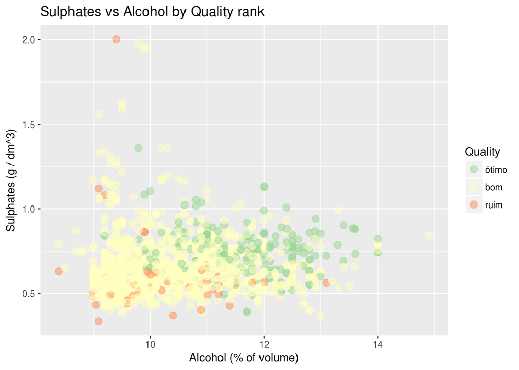

Aqui com esse gráfico fica bem claro que vinhos bons, em geral, possuem uma gradação alcóolica maior do que 10% e *sulphates* maior do que 0.6

# Gráficos finais e sumário

### Primeiro Gráfico

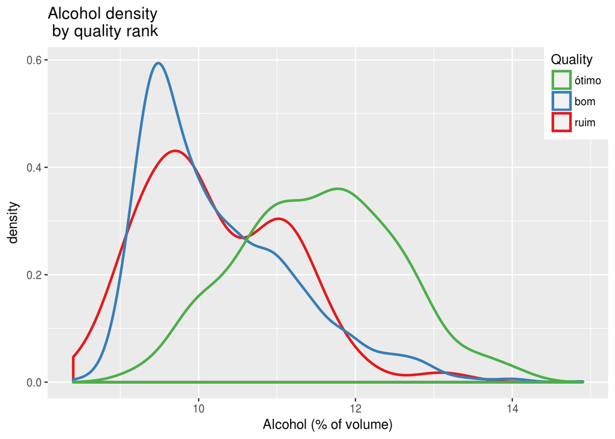

```r
density_plot_func(col = "quality.label",
                  x_str = "alcohol",
                  xl = "Alcohol (% of volume)",
                  t = "Alcohol density\n by quality rank",
                  lt = "Quality")+
                  theme(legend.justification=c(1,1),
                  legend.position=c(1,1))
```

### Descrição do primeiro gráfico

Além do gráfico, podemos ver na tabela abaixo que realmente existe uma diferença entre cada tipo de vinho :)

```r
by(wineQualityReds$alcohol, wineQualityReds$quality.label,  summary)
```

```
## wineQualityReds$quality.label: ruim
##    Min. 1st Qu.  Median    Mean 3rd Qu.    Max.
##    8.40    9.60   10.00   10.22   11.00   13.10
## --------------------------------------------------------
## wineQualityReds$quality.label: bom
##    Min. 1st Qu.  Median    Mean 3rd Qu.    Max.
##    8.40    9.50   10.00   10.25   10.90   14.90
## --------------------------------------------------------
## wineQualityReds$quality.label: ótimo
##    Min. 1st Qu.  Median    Mean 3rd Qu.    Max.
##    9.20   10.80   11.60   11.52   12.20   14.00
```

### Segundo Gráfico

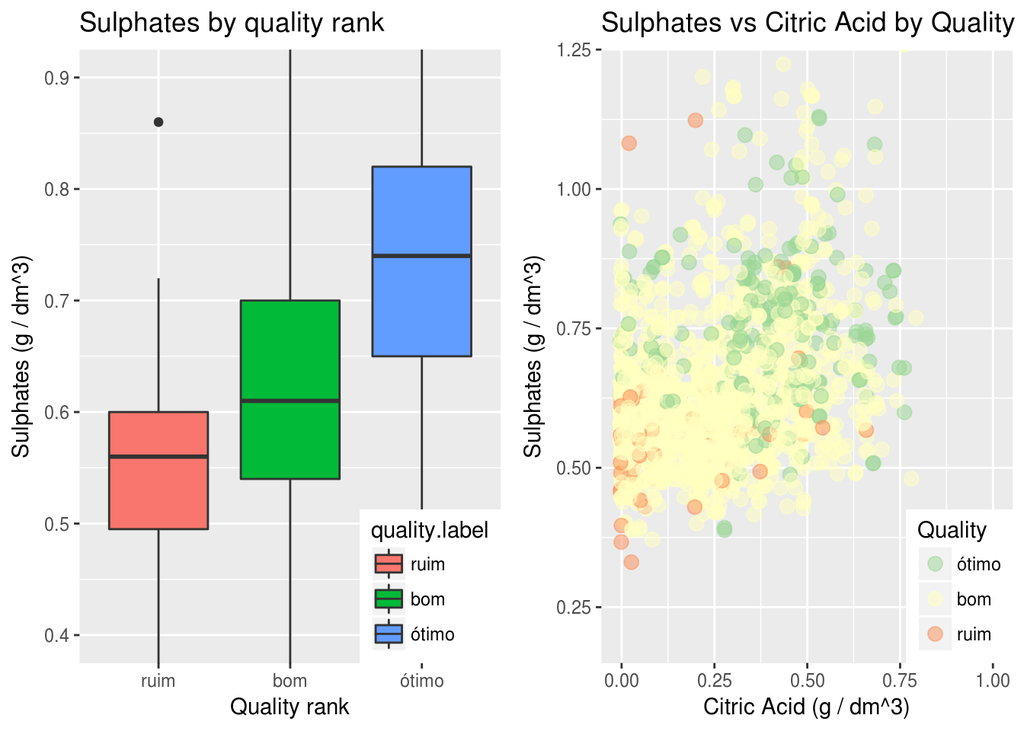

```r
final_plot_two_1 = ggplot(data = wineQualityReds,
                          aes(x=quality.label,
                          y = sulphates,
                          fill = quality.label)) +
                          geom_boxplot()+
                          xlab("Quality rank")+
                          ylab("Sulphates (g / dm^3)")+
                          ggtitle("Sulphates by quality rank")+
                          coord_cartesian(ylim=c(0.4,0.9))+
                          theme(legend.justification=c(1,0),
                                legend.position=c(1,0))

final_plot_two_2 = point_plot_func(x_str = "citric.acid",
                                   y_str = "sulphates",
                                   yl = "Sulphates (g / dm^3)",
                                   xl = "Citric Acid (g / dm^3)",
                                   t = "Sulphates vs Citric Acid by Quality")+
                                  coord_cartesian(ylim=c(0.2,1.2))+
                                  theme(legend.justification=c(1,0),
                                      legend.position=c(1,0))

grid.arrange(final_plot_two_1, final_plot_two_2, ncol=2)
```

### Descrição do Segundo Gráfico

O comportamento da variável *sulphates* tem um comportamento bem diferente em relação aos três tipos, isso é muito bom :)

No segundo gráfico vemos que em geral, vinhos bons possuem o nível de *sulphates* maior do que 0.6.

Outra observação é em relação ao segundo gráfico, que mostra a relação entre o nível de *sulphates* e *citric.acid*. Podemos perceber que vinhos classicados como ótimo em geral possuem um maior nível de *citric.acid* e também de *sulphates*.

```r
by(wineQualityReds$sulphates, wineQualityReds$quality.label,  summary)
```

```
## wineQualityReds$quality.label: ruim
##    Min. 1st Qu.  Median    Mean 3rd Qu.    Max.
##  0.3300  0.4950  0.5600  0.5922  0.6000  2.0000
## --------------------------------------------------------
## wineQualityReds$quality.label: bom
##    Min. 1st Qu.  Median    Mean 3rd Qu.    Max.
##  0.3700  0.5400  0.6100  0.6476  0.7000  1.9800
## --------------------------------------------------------
## wineQualityReds$quality.label: ótimo
##    Min. 1st Qu.  Median    Mean 3rd Qu.    Max.
##  0.3900  0.6500  0.7400  0.7435  0.8200  1.3600
```

```r
by(wineQualityReds$citric.acid, wineQualityReds$quality.label,  summary)
```

```
## wineQualityReds$quality.label: ruim
##    Min. 1st Qu.  Median    Mean 3rd Qu.    Max.
##  0.0000  0.0200  0.0800  0.1737  0.2700  1.0000
## --------------------------------------------------------
## wineQualityReds$quality.label: bom
##    Min. 1st Qu.  Median    Mean 3rd Qu.    Max.
##  0.0000  0.0900  0.2400  0.2587  0.4000  0.7900
## --------------------------------------------------------
## wineQualityReds$quality.label: ótimo
##    Min. 1st Qu.  Median    Mean 3rd Qu.    Max.
##  0.0000  0.3000  0.4000  0.3765  0.4900  0.7600
```

### Terceiro Gráfico

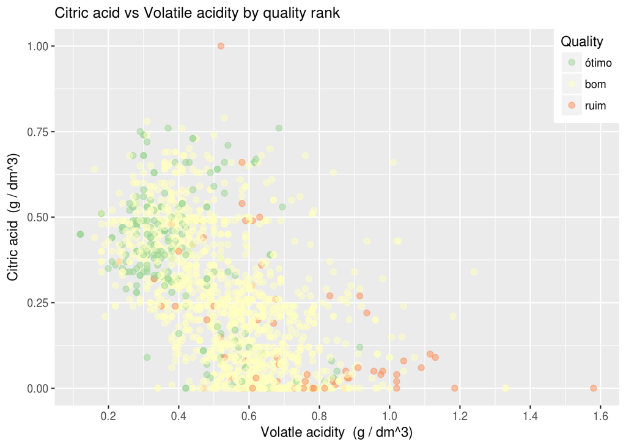

```r
ggplot()+
  geom_point(alpha = 0.5,
             data = wineQualityReds,
             aes(x=volatile.acidity,
                 y = citric.acid,
                 color = quality.label),
             size=2)+
  scale_x_continuous(breaks = seq(0,1.6,0.2))+
  ylab("Citric acid  (g / dm^3)")+
  xlab("Volatle acidity  (g / dm^3)")+
  ggtitle("Citric acid vs Volatile acidity by quality rank")+
  scale_color_brewer(palette="Spectral",
                     type = 'div',
                     guide = guide_legend(title = 'Quality',
                                          reverse = T))+
  theme(plot.title = element_text(size=12),
        legend.justification=c(1,1),
        legend.position=c(1,1))
```

### Descrição do Terceiro Gráfico

A ideia de fazer esse gráfico foi verificar a relação entre as variáveis *citric.acid* e *volatile.acidity* nos diferentes níveis de qualidade. Podemos ver claramente que quão menor o nível de *volatile.acidity* e maior o de *citric.acid*, melhor será a qualidade do vinho. Vinhos classificados como ruins tem um alto valor de *volatile.acidity* e um baixíssimo de *citric.acid* :)

```r
by(wineQualityReds$citric.acid, wineQualityReds$quality.label,  summary)
```

```
## wineQualityReds$quality.label: ruim
##    Min. 1st Qu.  Median    Mean 3rd Qu.    Max.
##  0.0000  0.0200  0.0800  0.1737  0.2700  1.0000
## --------------------------------------------------------
## wineQualityReds$quality.label: bom
##    Min. 1st Qu.  Median    Mean 3rd Qu.    Max.
##  0.0000  0.0900  0.2400  0.2587  0.4000  0.7900
## --------------------------------------------------------
## wineQualityReds$quality.label: ótimo
##    Min. 1st Qu.  Median    Mean 3rd Qu.    Max.
##  0.0000  0.3000  0.4000  0.3765  0.4900  0.7600
```

```r
by(wineQualityReds$volatile.acidity, wineQualityReds$quality.label,  summary)
```

```
## wineQualityReds$quality.label: ruim
##    Min. 1st Qu.  Median    Mean 3rd Qu.    Max.
##  0.2300  0.5650  0.6800  0.7242  0.8825  1.5800
## --------------------------------------------------------
## wineQualityReds$quality.label: bom
##    Min. 1st Qu.  Median    Mean 3rd Qu.    Max.
##  0.1600  0.4100  0.5400  0.5384  0.6400  1.3300
## --------------------------------------------------------
## wineQualityReds$quality.label: ótimo
##    Min. 1st Qu.  Median    Mean 3rd Qu.    Max.
##  0.1200  0.3000  0.3700  0.4055  0.4900  0.9150
```

# Reflexão

Quando vi que teria a oportunidade de estudar esse dataset eu fiquei muito animado! Não sou um grande entendedor de vinhos, mas sou de família italiana, ou seja, ao invés de sangue é vinho que corre em minhas veias :P

Para comprovar isso, fiz todos os gráficos. E analisando-os, realmente vi que os vinhos de qualidade boa se concentram em determinadas regiões dos gráficos para cada variável.

Tive algumas dificuldades durante o processo, principalmente por não entender direito o comportamento de cada variável na qualidade do vinho. Eu realmente não sabia por onde começar, por quais variáveis combinar e assim por diante! Conhecer pacotes como o *cor()* foi essencial para que eu conseguisse realizar esse projeto :)

Como sugestão para um trabalho futuro, acho que seria bem legal adicionar uma variável que seria o tipo do vinho e a região de onde ele foi feito. Pelo menos eu acho que a região tem um fator relativamente importante na qualidade … Ahh, outra coisa, a safra, i.é, o mês que ele foi produzido.. acho que cruzar isso com dados metereológicos pode dar muitos insights :)